# LBRAI2219 - Modélisation des systèmes biologiques

Modèle APSIM pour deux cultures

Maxime CORNEZ

24/05/2024

# 1 Résumé

Cette étude présente le développement et l’évaluation d’un modèle dualisé basé sur APSIM pour simuler la co-culture de maïs et d’une seconde espèce (courge, haricot ou salade) sur un profil de sol en trois horizons. Partant d’un simulateur monoculture validé (vérification de la cohérence hydrique : transpiration ≤ offre en eau), nous avons étendu la procédure afin de répartir quotidiennement la ressource hydrique entre les deux cultures, proportionnellement à leurs demandes relatives, tout en conservant les dynamiques racinaires et foliaires propres à chaque espèce. Les simulations sur 30 jours (30–60 DAS) ont permis de comparer :

- les réserves d’eau résiduelles (horizons 1–3),
- le ratio Offre/Demande (O/D) journalier et le nombre de jours de stress hydrique (O/D < 1),
- la production de biomasse cumulée,
- l’efficience d’usage de l’eau (WUE) pour chaque scénario.

Les résultats montrent qu’en monoculture, le maïs atteint 416 g·m⁻² à J60 (pente de 12 g·m⁻²·j⁻¹) et une WUE de 5,48 g·m⁻²/mm. En interculture, la biomasse maïs chute de 33–58 % selon l’espèce associée, tandis que l’espèce secondaire capte jusqu’à 120–130 g·m⁻². La densité relative du maïs (0,1–0,9) et le choix de l’associé influencent significativement (ANOVA p < 10⁻⁹) la biomasse finale. Les analyses de sensibilité révèlent qu’une faible densité de maïs limite modérément la perte de rendement (salade > haricot > courge).

# 2 Introduction

## 2.1 État de l’art

L’agriculture moderne est soumise à de nombreux défis à l’heure actuelle : elle se doit de produire assez pour nourrir la population mondiale, tout en respectant au mieux l’environnement et en s’adaptant aux changements climatiques. Or, les terres disponibles pour l’agriculture ne sont pas illimitées et la pression sur les ressources naturelles est de plus en plus forte. De plus, les ressources en eau et en terre ne sont pas distribuées de manière égale sur la planète, ce qui rend la tâche encore plus complexe (Dudgeon et al. 2006).  
L’agriculture dépend de ces deux ressources presque autant qu’elle dépend du soleil, or avec l’augmentation de la population mondiale et les changements climatiques, la disponibilité de l’eau et des terres agricoles est mise à rude épreuve.  
Aujourd’hui, si l’on combine les terres arables et les prairies,ces deux biomes sont les plus présent à la surface de la Terre, occupant environ 40 % de la surface terrestre. En outre, les terres agricoles sont souvent utilisées de manière intensive, avec des pratiques telles que la monoculture, l’utilisation excessive d’engrais et de pesticides, et la déforestation pour créer de nouvelles terres agricoles. Ces pratiques ont des conséquences néfastes sur l’environnement, notamment la perte de biodiversité, la dégradation des sols et la pollution de l’eau (Foley et al. 2005).

La recherche agronomique s’est orientée vers des pratiques agricoles plus durables, telles que l’agroécologie, l’agriculture de conservation et la permaculture. Ces pratiques visent à réduire l’impact environnemental de l’agriculture tout en maintenant des rendements élevés. Elles reposent sur une meilleure compréhension des interactions entre les plantes, les sols et les écosystèmes, ainsi que sur l’utilisation de techniques de gestion intégrée des cultures (Bondeau et al. 2007).

Pour s’adapter aux épisodes de stress hydrique et thermique, les plantes déploient un éventail de réponses physiologiques coordonnées. D’une part, elles ferment partiellement, voire totalement, leurs stomates pour réduire les pertes d’eau, ajustent leur croissance, celle de leurs racines et celle de leur feuillage, pour limiter l’évapotranspiration et modifient l’orientation et la taille de leurs feuilles afin d’optimiser la capture de la lumière sans souffrir de surchauffe. D’autre part, elles optimisent l’efficacité de leur utilisation de l’eau par des ajustements biochimiques, comme l’accumulation d’osmolytes, et par des modifications de la composition de leur cuticule pour diminuer la perte d’eau.  
Au cœur de ces stratégies, l’architecture racinaire joue un rôle décisif. Un enracinement profond permet d’accéder aux réserves hydriques des horizons profonds, tandis qu’une croissance rapide des racines favorise une exploration efficace du volume de sol. La capacité à répartir finement les racines dans les différents niveaux du sol accroît considérablement les probabilités de rencontrer des poches d’humidité. De plus, certaines plantes développent une plasticité racinaire importante, ajustant dynamiquement la ramification et l’élongation des racines selon la disponibilité locale de l’eau, et renforcent leurs interactions avec les champignons mycorhiziens pour améliorer l’absorption hydrique et minérale. Ces traits racinaires combinés forment un arsenal adaptatif essentiel pour maintenir la croissance et la productivité en conditions de déficit hydrique(Munns 2002).

Ce projet traitera plus spécifiquement de la permaculture et des intercultures, techniques visant à maximiser l’espace disponible et les ressources pour deux cultures ou plus occupant le même espace. Ces techniques sont de plus en plus populaires dans les systèmes agricoles durables, car elles permettent de diversifier les cultures, d’améliorer la santé des sols et de réduire les besoins en intrants chimiques (Brooker et al. 2015).

Le maïs (*Zea mays L.*) est l’une des céréales les plus cultivées au monde, environ 850 millions de tonnes produites par an sur approximativement 162 millions d’hectares (Yara 2018). Son métabolisme en C₄ lui garantit une photosynthèse très efficace et une bonne tolérance aux fortes températures. Toutefois, il reste fortement dépendant de l’eau, en particulier durant la floraison et la pollinisation, lorsque le stress hydrique peut provoquer des pertes de rendement importantes. Son réseau racinaire dense et profond, pouvant aller jusqu’à 1m80, lui permet une captation efficace de l’eau et des nutriments (Barnabás, Jäger, and Fehér 2008).

Il serait intéressant d’optimiser ces surfaces de culture en alliant les plants de maïs avec d’autres plantes pouvant bénéficier de cet espace. La sélection des bonnes variétés de plante entrainera un symbiose, améliorant le rendement globale de production et permettant ainsi une meilleure valorisation de l’eau et des ressources.  
Les cultures le plus souvent associées au maïs sont souvent des espèces de petite taille, profitant de l’ombrage apporté par les feuilles du maïs ou de la structure de sa tige(Brooker et al. 2015; Dong et al. 2022; Nassary, Baijukya, and Ndakidemi 2020; Zhang and Li 2003). On retrouve par exemple :

- des légumineuses comme les haricots (*Phaseolus vulgaris*) : ils fixent l’azote atmosphérique dans le sol, améliorant ainsi la fertilité du sol et réduisant le besoin en engrais azotés pour le maïs et se servent des tiges de maïs comme support pour leurs tiges (Mudare et al. 2022).
- des courges (*Cucurbita pepo*) : elles ont de grandes feuilles qui fournissent de l’ombre au sol, réduisant l’évaporation de l’eau et maintenant une température du sol plus fraîche, ce qui est bénéfique pour le maïs. Elles aident également à contrôler les mauvaises herbes en couvrant le sol (Cryan et al. 2025).
- des salades (*Lactuca sativa*) : elles ont une croissance rapide et peuvent être récoltées avant que le maïs ne devienne trop grand, permettant ainsi une utilisation efficace de l’espace. Elles protègent le sol et exploitent la strate inférieure (Brennan 2013).

## 2.2 Importance de l’approche par modélisation

Comme l’a dit Samuel P. Huntington “Nous avons besoin de modèles explicites ou implicites pour pouvoir ordonner et généraliser la réalité, comprendre les relations causales entre les phénomènes, anticiper et, si nous avons de la chance, prédire les développements futurs, distinguer l’essentiel de l’accessoire et nous indiquer les chemins à suivre pour atteindre nos objectifs”. Un modèle n’est jamais une parfaite représentation de la réalité, mais il permet de simplifier et d’organiser les connaissances pour mieux comprendre les systèmes complexes. En agronomie, la modélisation est un outil essentiel pour simuler le comportement des cultures et des systèmes agricoles, en tenant compte des interactions entre les plantes, le sol et l’environnement, sans devoir nécessairement passer par une étape expérimentale longue et coûteuse (Tremblay and Wallach 2004).

Le modèle APSIM (pour Agricultural Production Systems sIMulator) est un modèle de simulation de culture qui permet de simuler la croissance des cultures, la dynamique du sol et les interactions entre les plantes et l’environnement. Il a été développé en 1995 par une équipe multiuniversitaire et est encore utilisé et amélioré à ce jour. APSIM est un modèle modulaire, ce qui signifie qu’il peut être adapté à différents systèmes agricoles et à différentes conditions environnementales. Il est capable de simuler la croissance des cultures en tenant compte des facteurs climatiques, hydriques et nutritionnels, ainsi que des interactions entre les plantes et le sol (McCown et al. 1996; Keating et al. 2003).

# 3 Matériel et méthodes

## 3.1 Modèles

L’étude repose sur une modélisation d’APSIM en combinant deux cultures (maïs et autre) en interculture. Le modèle APSIM est utilisé pour simuler la croissance des cultures, la dynamique du sol et les interactions entre les plantes et l’environnement.

- **APSIM mono** : Ce modèle a pour but de simuler la production de biomasse chez le maïs en prenant en compte à la fois les contraintes hydriques et lumineuses. Il s’appuie d’une part sur les équations de Monteith, qui relient la croissance à la quantité de rayonnement intercepté, et d’autre part sur le concept d’efficience de transpiration, qui traduit la conversion de l’eau prélevée en biomassе sous stress hydrique. Ensemble, ces deux approches permettent de quantifier l’impact combiné de la lumière et de la disponibilité en eau sur le développement de la culture. Hammer (2009)  
  La version présentée ici a été légèrement remise en forme par Alice Falzon et moi-même afin d’en améliorer l’érgonomie et la facilité d’utilisation.
- **APSIM duo** : Ce modèle est une extension du modèle mono, qui permet de simuler la production de biomasse pour deux cultures en interculture. Il prend en compte les interactions entre les deux cultures pour l’eau et la profondeur des racines. Le modèle est capable de simuler la croissance des deux cultures en tenant compte des facteurs climatiques et hydriques, ainsi que des interactions entre les plantes et le sol. Le modèle inclut un “arbitre” déterminant quelle culture recevra prioritairement l’eau en cas de déficit hydrique, cet arbitre est inclu directement dans la fonction du modèle.  
  Par simplicité, l’hypothèse que les deux cultures n’ont pas d’intéractions au niveau de la lumière a été faite, ce qui signifie que la lumière est répartie entre les deux cultures selon la disponibilité.  
  La conversion de APSIM mono vers duo a représenté la plus grande partie de ce projet.

Le plan de modélisation est structuré comme suit :

1. Obtention des paramètres de cultures pour chaque culture désirée. Puis des paramètres du sol et de l’expansion foliaire
2. Obtention des paramètres météo, soit via un jeu de données généré artificiellement, soit via un jeu de données réelles obtenu via Open-Meteo (“🌤️ Free Open-Source Weather API Open-Meteo.com” 2025) ; sélection de la source via le switch installé dans le code.
3. Fixation des densités de culture.
4. Simulation de la production de biomasse avec APSIM.
   1. Pour le maïs seul avec Apsim mono.
   2. En combinant le maïs avec une autre culture avec Apsim duo.
5. Analyse et comparaison des résultats.

## 3.2 Packages et outils utilisés

- **Importation et manipulation de données**
  - *readxl* : permet de lire directement des fichiers Excel (.xls, .xlsx) en important les feuilles de calcul sous forme de data frames.
  - *dplyr* et *tidyr* : offrent un ensemble de fonctions (p. ex. filter(), select(), mutate()) pour nettoyer, transformer et reformater les données de façon claire et fluide.
  - *tibble* : fournit une version moderne des data frames, plus strictes et plus lisibles, avec un meilleur affichage dans la console.
- **Rapports et mise en forme**
  - *knitr* : facilite la génération de rapports dynamiques (R Markdown, LaTeX, HTML) en mélangeant code R et texte narratif.
- **Visualisation**
  - *ggplot2* : propose un système de grammaire graphique puissant pour créer des graphiques élégants et personnalisables (histogrammes, nuages de points, séries temporelles, etc.) à partir de data frames.
- **Accès et traitement de données web**
  - *httr* : facilite les requêtes HTTP (GET, POST, authentification) pour interagir avec des API ou récupérer des ressources distantes.
  - *jsonlite* : convertit des fichiers JSON en objets R (et inversement), ce qui rend l’exploitation des réponses d’API et le stockage des données JSON plus accessibles.
- **Programmation fonctionnelle**
  - *purrr* : offre un ensemble de fonctions pour la programmation fonctionnelle en R (p. ex. map(), reduce()) et le traitement vectorisé de listes.
- **Modélisation statistique**
  - *lme4* : permet d’ajuster des modèles linéaires et généralisés à effets mixtes (fonctions lmer(), glmer(), etc.) pour prendre en compte à la fois des effets fixes et des effets aléatoires.
  - *broom* : convertit les résultats de modèles statistiques en data frames « tidy » pour un traitement et un reporting facilités (tidy(), glance(), augment()).
  - *multcomp* : fournit des outils pour réaliser des comparaisons multiples (tests de Tukey, Dunnett, etc.) à partir de modèles linéaires et mixtes.

```r
# Packages requis
library(readxl)
library(dplyr)
library(tidyr)
library(knitr)
library(tibble)
library(lme4)
library(ggplot2)
library(jsonlite)
library(httr)
library(broom)
library(purrr)
library(multcomp)
```

ChatGPT a été utilisé a des fins de reformulations de phrases, l’entièreté du texte a été relu, vérifié et approuvé.

## 3.3 Données d’entrée

### 3.3.1 Paramètres des cultures

Dans la mesure du possible, les paramètres ont été extraits de la littérature. Lorsque certaines données faisaient défaut, des extrapolations ont été réalisées à partir des connaissances acquises au cours de ma formation, dans un but de différenciation de l’espèce par rapport au maïs. Seules les données relatives au maïs peuvent être considérées comme pleinement fiables, puisqu’elles proviennent d’un exercice pratique donné par le professeur Draye Rouphael and Colla (2005).

```r
mais <- list(
  RUE               = 1.6,   # Radiation Use Efficiency [g/MJ]
  TEc               = 9,     # Coefficient d'efficience de la transpiration [Pa]
  VPR               = 20,    # Vitesse production de racines [mm/jour]
  CroissPotLAI      = 0.1,   # Croissance potentielle du LAI
  k                 = 0.45,  # Coefficient d'extinction de la lumière
  LAI_initial       = 1.5,
  Biomasse_initiale = 45
)

sorgho <- list(
  RUE               = 1.25,  # Radiation Use Efficiency [g/MJ]
  TEc               = 9,     # Coefficient d'efficience de la transpiration [Pa]
  VPR               = 20,    # Vitesse production de racines [mm/jour]
  CroissPotLAI      = 0.1,   # Croissance potentielle du LAI
  k                 = 0.45,  # Coefficient d'extinction de la lumière
  LAI_initial       = 1.5,
  Biomasse_initiale = 45
)

haricot <- list(
  RUE               = 1.78,  # Radiation Use Efficiency [g/MJ]
  TEc               = 4.9,   # Coefficient d'efficience de la transpiration [Pa]
  VPR               = 13.5,  # Vitesse production de racines [mm/jour]
  CroissPotLAI      = 0.1,   # Croissance potentielle du LAI
  k                 = 0.6,   # Coefficient d'extinction de la lumière
  LAI_initial       = 1.0,
  Biomasse_initiale = 20
)

courge <- list(
  RUE               = 4.1,   # Radiation Use Efficiency [g/MJ]
  TEc               = 2.9,   # Coefficient d'efficience de la transpiration [Pa]
  VPR               = 15,    # Vitesse production de racines [mm/jour]
  CroissPotLAI      = 0.12,  # Croissance potentielle du LAI
  k                 = 0.72,  # Coefficient d'extinction de la lumière
  LAI_initial       = 0.8,
  Biomasse_initiale = 35
)


salade <- list(
  RUE               = 1.2,   # Radiation Use Efficiency [g/MJ]
  TEc               = 3,     # Coefficient d'efficience de la transpiration [Pa]
  VPR               = 8,     # Vitesse production de racines [mm/jour]
  CroissPotLAI      = 0.15,  # Croissance potentielle du LAI
  k                 = 0.5,   # Coefficient d'extinction de la lumière
  LAI_initial       = 0.6,
  Biomasse_initiale = 15
)
```

### 3.3.2 Paramètres du sol

Paramètres générés artificiellement pour avoir un sol d’ 1m d’épaisseur contenant un minimum de 40mm d’eau et un maximum de 100mm d’eau. Les scénarios envisagés ne prévoient pas de recharge des horizons par précipitation d’une quelconque autre façon.  
L’hyphothèse que le kl est une valeur propre au sol a été posée pour simplifier les calculs. En réalité, le kl est variable selon de nombreux critères propres au sol et aux plantes occupant le sol.

```r
soil_params <- data.frame(
  Horizon     = c(1, 2, 3),
  Epaisseur   = c(300, 300, 400),   # mm
  li          = c(40,  40,  40),    # Limite inférieure d'eau
  ls          = c(100, 100, 100),   # Limite supérieure d'eau
  es          = c(100, 100, 100),   # Eau disponible dans sol (= sw)
  es_h        = c(40, 30, 30),      # Eau disponible dans sol par horizon ; es_h1+es_h2+es_h3 = es
  kl          = c(0.06, 0.05, 0.05) # Taux d'extraction [mm/jour]
)
```

### 3.3.3 Expansion foliaire

```r
# Culture 1
expansion_foliaire <- data.frame(
  OD  = c(0.5, 1.5, 4), # Offre sur demande
  CEF = c(0,   1,   1)  # Coefficient d'expansion foliaire
)

# Culture 2
expansion_foliaire2 <- data.frame(
  OD  = c(0.4, 1.0, 3.5), # Offre sur demande
  CEF = c(0,   0.8, 1)    # Coefficient d'expansion foliaire

)
```

### 3.3.4 Paramètres météo

```r
# Données météo réelles
lat <- 50.666265; lon <- 4.622322   # Localisation de la zone d'étude : 50.666265 ; 4.622322 = batiment De serres
start_date <- "2024-06-01"; end_date <- "2024-06-30"           # Période de simulation
res <- GET("https://archive-api.open-meteo.com/v1/archive",    # Obtention des données de la station météo belge
           query = list(latitude = lat, longitude = lon,
                        start_date = start_date, end_date = end_date,
                        daily = "temperature_2m_max,temperature_2m_min,shortwave_radiation_sum",
                        timezone = "Europe/Brussels"))
meteo_data <- fromJSON(content(res, "text"))$daily             # Importation du fichier de données JSON

meteo_df <- as.data.frame(meteo_data) %>%
  rename(Date = time, Tmax = temperature_2m_max,
         Tmin = temperature_2m_min, Radiation = shortwave_radiation_sum) %>%

  mutate(Jours = 1:n(),  # fonctions pour calculer vdp
         svpTmax = 6.1078 * exp(17.269 * Tmax / (237.3 + Tmax)) * 0.10,
         svpTmin = 6.1078 * exp(17.269 * Tmin / (237.3 + Tmin)) * 0.10,
         VPDcalc = 0.75 * (svpTmax - svpTmin) * 10)

# Génération de données artificielles

facteur_externe <- data.frame(
  # Durée de la simulation (jours)
  Jours = 30:60,

  # Radiation (MJ/m2)
  Radiation = c(
    27, 27, 14, 24, 23, 21,
    23, 25, 17, 14, 26, 26,
    10, 26, 30, 27, 27, 29,
    27, 26, 25, 23, 14, 25,
    22, 20, 22, 24, 28, 25, 25
  ),

  # Tmax (°C)
  Tmax = c(
    32.3, 31.0, 26.6, 26.0, 26.6, 29.5,
    30.8, 32.5, 32.3, 25.2, 27.8, 28.2,
    27.3, 28.6, 28.6, 28.3, 27.6, 31.0,
    35.0, 34.3, 31.2, 32.7, 29.9, 30.8,
    31.2, 28.4, 27.7, 31.4, 33.0, 33.2, 32.7
  ),

  # Tmin (°C)
  Tmin = c(
    16.4, 15.8, 15.6, 10.0, 11.7, 13.0,
    16.5, 13.8, 16.7, 16.7, 15.8, 12.8,
    17.3, 11.3, 13.7, 13.4, 13.7, 12.2,
    14.7, 20.4, 15.5, 17.9, 18.4, 16.0,
    16.1, 18.0, 14.9, 16.0, 16.2, 17.2, 18.3
  ),

  # VPDobs (hPa)
  VPDobs = c(
    19, 17, 16, 14, 12, 15,
    18, 19, 23, 21, 15, 14,
    20, 16, 17, 17, 15, 15,
    16, 17, 18, 21, 22, 17,
    18, 20, 18, 19, 19, 20, 21
  )
)

# Fonction pour calculer saturated vapour pressure (SVP)
svp <- function(T) { # satured vapour pressure [kPa]
  6.1078 * exp(17.269 * T / (237.3 + T)) * 0.10
}

# Application à Tmax
facteur_externe$svpTmax <- svp(facteur_externe$Tmax) # pression saturante à Tmax

# Application à Tmin
facteur_externe$svpTmin <- svp(facteur_externe$Tmin) # pression saturante à Tmin

VPDfrac <- 0.75 # par défaut on prend 0.75


# Fonction pour calculer VPDcalc
calc_VPDcalc <- function(svpTmax, svpTmin, VPDfrac) {
  VPDfrac * (svpTmax - svpTmin)*10
}

# Ajout de la colonne VPDcalc
facteur_externe$VPDcalc <- calc_VPDcalc(
  svpTmax  = facteur_externe$svpTmax,
  svpTmin  = facteur_externe$svpTmin,
  VPDfrac  = VPDfrac
)

# Choix de la source de données : "reel" ou "artificiel" (switch)

data_source <- "artificiel"    # mettre "artificiel" si on veut le jeu généré

if (data_source == "reel") {
  facteur_externe <- meteo_df %>%
    dplyr::select(Jours, Radiation, Tmax, Tmin, VPDcalc)
} else if (data_source == "artificiel") {
  facteur_externe <- facteur_externe %>%
    dplyr::select(Jours, Radiation, Tmax, Tmin, VPDcalc)
} else {
  stop("data_source doit être 'reel' ou 'artificiel'")
}
```

### 3.3.5 Densité des deux cultures

```r
Densite1 <- 0.5 # Densité de la culture 1
Densite2 <- 1-Densite1 # Densité de la culture 2
```

## 3.4 Modèles utilisés

### 3.4.1 APSIM monoculture

```r
# Ce script simule la croissance d'une culture en fonction de l'eau disponible et de la radiation solaire pour une seule culture

simulate <- function(facteur_externe, soil_params, culture_params, expansion_foliaire) {
  n_days <- nrow(facteur_externe)

  # Vecteurs pour l'eau disponible par horizon
  ES1 <- numeric(n_days)
  ES2 <- numeric(n_days)
  ES3 <- numeric(n_days)

  # Initialisation des réserves d'eau pour chaque horizon
  ES1[1] <- soil_params$es_h[1]
  ES2[1] <- soil_params$es_h[2]
  ES3[1] <- soil_params$es_h[3]

  # Initialisation de la LAI dynamique
  LAI_dyn <- numeric(n_days)
  LAI_dyn[1] <- culture_params$LAI_initial

  # Préparation d'un data frame pour stocker les résultats totaux
  results <- data.frame(
    Jour = facteur_externe$Jours,
    Tot_ES = numeric(n_days),
    Pot_Supply = numeric(n_days),
    Pot_Demand = numeric(n_days),
    Transpiration = numeric(n_days),
    LAI = numeric(n_days),
    I = numeric(n_days),
    Biomasse_1 = numeric(n_days),
    Biomasse_2 = numeric(n_days),
    O_D = numeric(n_days),
    Biomasse_reelle = numeric(n_days),
    Biomasse_cum = numeric(n_days),
    ES1 = numeric(n_days),
    ES2 = numeric(n_days),
    ES3 = numeric(n_days),
    rdepth = numeric(n_days)
  )
  results$LAI[1] <- LAI_dyn[1]

  # Fonction pour calculer l'effet d'expansion foliaire
  leaf_exp_effect <- function(sdratio, expansion_foliaire) {
    # Si le ratio est en-deçà du premier seuil, on renvoie la première valeur,
    # si au-dessus du dernier, on renvoie la dernière,
    # sinon on effectue une interpolation linéaire.
    if(sdratio <= expansion_foliaire$OD[1]) {
      return(expansion_foliaire$CEF[1])
    } else if (sdratio >= tail(expansion_foliaire$OD,1)) {
      return(tail(expansion_foliaire$CEF,1))
    } else {
      for(j in 1:(nrow(expansion_foliaire)-1)){
        if(sdratio >= expansion_foliaire$OD[j] && sdratio < expansion_foliaire$OD[j+1]){
          return(expansion_foliaire$CEF[j] +
                   (sdratio - expansion_foliaire$OD[j]) *
                   (expansion_foliaire$CEF[j+1] - expansion_foliaire$CEF[j]) /
                   (expansion_foliaire$OD[j+1] - expansion_foliaire$OD[j]))
        }
      }
    }
  }

  # Boucle de simulation pour chaque jour
  for (i in 1:n_days) {
    DAS <- facteur_externe$Jours[i]
    # La profondeur racinaire effective est limitée par la somme des épaisseurs
    profondeur_totale <- sum(soil_params$Epaisseur)
    rdepth <- min(DAS * culture_params$VPR, profondeur_totale)
    results$rdepth[i] <- rdepth


    # Calcul des offres potentielles pour chaque horizon
    of1 <- ifelse(rdepth >= soil_params$Epaisseur[1], 1, rdepth / soil_params$Epaisseur[1]) * ES1[i] * soil_params$kl[1]
    of2 <- ifelse(rdepth <= soil_params$Epaisseur[1], 0,
                  ifelse(rdepth > soil_params$Epaisseur[1] + soil_params$Epaisseur[2],
                         1, (rdepth - soil_params$Epaisseur[1]) / soil_params$Epaisseur[2])) * ES2[i] * soil_params$kl[2]
    of3 <- ifelse(rdepth <= (soil_params$Epaisseur[1] + soil_params$Epaisseur[2]), 0,
                  (rdepth - soil_params$Epaisseur[1] - soil_params$Epaisseur[2]) / soil_params$Epaisseur[3]) * ES3[i] * soil_params$kl[3]

    Pot_Supply <- of1 + of2 + of3

    # Calcul de l'effet lumineux : LI = 1 - exp(-k * LAI_dyn)
    li <- 1 - exp(-culture_params$k * LAI_dyn[i])

    # Calcul de la demande potentielle
    rad <- facteur_externe$Radiation[i]
    VPDcalc <- facteur_externe$VPDcalc[i]
    Pot_Demand <- rad * li * culture_params$RUE * (VPDcalc / 10) / culture_params$TEc

    # Transpiration journalière
    transpiration <- min(Pot_Supply, Pot_Demand)

    # Stockage des résultats du jour
    results$Tot_ES[i] <- ES1[i] + ES2[i] + ES3[i]
    results$Pot_Supply[i] <- Pot_Supply
    results$Pot_Demand[i] <- Pot_Demand
    results$Transpiration[i] <- transpiration
    results$LAI[i] <- LAI_dyn[i]

    # Calcul du ratio offre/demande (si demande > 0)
    sdratio <- if (Pot_Demand > 0) Pot_Supply / Pot_Demand else 0
    # Calcul de l'effet d'expansion foliaire
    leaf_effect <- leaf_exp_effect(sdratio, expansion_foliaire)
    # delta LAI = leaf_effect * CroissPotLAI
    delta_LAI <- leaf_effect * culture_params$CroissPotLAI

    # Mise à jour de LAI pour le jour suivant
    if(i < n_days) {
      LAI_dyn[i + 1] <- LAI_dyn[i] + delta_LAI
    }

    # Mise à jour des réserves d'eau pour le jour suivant
    if (i < n_days) {
      if(Pot_Supply > 0) {
        ES1[i + 1] <- ES1[i] - (of1 / Pot_Supply) * transpiration
        ES2[i + 1] <- ES2[i] - (of2 / Pot_Supply) * transpiration
        ES3[i + 1] <- ES3[i] - (of3 / Pot_Supply) * transpiration
      } else {
        ES1[i + 1] <- ES1[i]
        ES2[i + 1] <- ES2[i]
        ES3[i + 1] <- ES3[i]
      }
    }
  }
  # Stockage des réserves d'eau dans le data frame des résultats
  results$ES1 <- ES1
  results$ES2 <- ES2
  results$ES3 <- ES3

  # Calcul des indices et biomasses après simulation
  results$I <- 1 - exp(-culture_params$k * results$LAI)
  results$Biomasse_1 <- (results$Pot_Supply * culture_params$TEc) / (facteur_externe$VPDcalc / 10)
  results$Biomasse_2 <- facteur_externe$Radiation * culture_params$RUE * results$I
  results$O_D <- ifelse(results$Pot_Demand == 0, 0, results$Pot_Supply / results$Pot_Demand)
  results$Biomasse_reelle <- ifelse(results$O_D > 1, results$Biomasse_2, results$Biomasse_1)
  results$Biomasse_cum <- culture_params$Biomasse_initiale + cumsum(results$Biomasse_reelle)

  return(results)
}
```

Le modèle apsim mono simule jour après jour l’équilibre entre l’offre en eau du sol et la demande hydrique induite par la radiation solaire, pour en déduire la croissance foliaire (LAI) et la production de biomasse.

1. **Réserves d’eau par horizon**  
   On initialise trois stocks d’eau (ES1, ES2, ES3) correspondant aux horizons du sol. À chaque pas de temps, la profondeur racinaire (rdepth) — croissante linéairement avec le jour après semis jusqu’à une limite totale — détermine la fraction de chaque horizon accessible à la plante. La « pot_supply » journalière est la somme des extractions potentielles sur chacun des trois horizons, calculées proportionnellement à la réserve restante et au coefficient d’extraction kl.
2. **Demande hydrique potentielle**  
   L’effet lumineux (LI) est obtenu par la loi de Beer-Lambert $(LI = 1 – exp(-k × LAI))$, puis la demande potentielle d’eau est calculée en combinant la radiation incidente (Rad), l’efficacité d’usage de la radiation RUE, l’effet de la VPD et le coefficient de transpiration TEc.
3. **Transpiration réelle et mise à jour du sol**  
   La transpiration quotidienne est le minimum entre l’offre et la demande. On retire alors de chaque horizon la fraction de cette transpiration proportionnelle à l’offre que cet horizon a contribué à la pot_supply, garantissant que l’on n’extrait jamais plus d’eau que disponible.
4. **Expansion foliaire**  
   Le ratio offre/demande (O/D) donne un indicateur de stress hydrique. Il alimente une table d’expansion foliaire (OD vs CEF) pour calculer le gain de LAI potentiel (delta_LAI). Le LAI est ainsi mis à jour pour le pas suivant, fermant la boucle rétroactive entre disponibilité en eau et surface foliaire.

**Production de biomasse**  
En post-traitement, deux biomasses journalières sont calculées :

1. **Biomasse à l’eau** : proportionnelle à la transpiration et à l’efficacité TEc,
2. **Biomasse à la lumière** : proportionnelle à la radiation et à RUE.

   La biomasse « réelle » retenue à chaque jour est choisie selon le ratio O/D (si > 1, production illimitée par l’eau, sinon limitée par la transpiration). Enfin, la biomasse cumulée est obtenue par somme des productions journalières à partir de la biomasse initiale.

Grâce à cette architecture, le modèle relie explicitement (1) la dynamique racinaire et la déplétion des réserves du sol, (2) l’arbitrage offre/demande hydrique via l’extension foliaire, et (3) la conversion de l’eau et de la lumière en biomasse, offrant ainsi un outil simple mais fidèle pour étudier la croissance sous contrainte hydrique.

### 3.4.2 APSIM combinant deux cultures

Apsim duo est une extension du modèle mono, permettant de simuler la croissance de deux cultures en interculture. Il prend en compte les interactions entre les deux cultures pour l’eau et la profondeur des racines. Le modèle est capable de simuler la croissance des deux cultures en tenant compte des facteurs climatiques et hydriques, ainsi que des interactions entre les plantes et le sol. Le modèle inclut un “arbitre” déterminant quelle culture recevra prioritairement l’eau en cas de déficit hydrique, cet arbitre est inclu directement dans la fonction du modèle.

```r
# Ce script simule la croissance de deux cultures en interculture en tenant compte de l'eau disponible et de la radiation solaire

# Densite des deux cultures
Densite1 <- 0.5 # Densité de la culture 1
Densite2 <- 1-Densite1 # Densité de la culture 2

simulate_two <- function(facteur_externe, soil_params, culture_params, culture2_params, expansion_foliaire, expansion_foliaire2, Densite1, Densite2) {
  n_days <- nrow(facteur_externe)

  # Initialisation du sol (réserves d'eau pour chaque horizon)
  ES1 <- numeric(n_days)
  ES2 <- numeric(n_days)
  ES3 <- numeric(n_days)
  ES1[1] <- soil_params$es_h[1]
  ES2[1] <- soil_params$es_h[2]
  ES3[1] <- soil_params$es_h[3]

  # Initialisation des profondeurs racinaires
  rdepth <- numeric(n_days)
  rdepth2 <- numeric(n_days)

  # Initialisation des LAI dynamiques pour chaque culture
  LAI1 <- numeric(n_days)
  LAI2 <- numeric(n_days)
  LAI1[1] <- culture_params$LAI_initial
  LAI2[1] <- culture2_params$LAI_initial

  # Initialisation de la biomasse pour chaque culture
  Biomasse1 <- numeric(n_days)
  Biomasse2 <- numeric(n_days)
  Biomasse1[1] <- culture_params$Biomasse_initiale
  Biomasse2[1] <- culture2_params$Biomasse_initiale

  # Initialisation des vecteurs de biomasse cumulée
  Biomasse_cum1 <- numeric(n_days)
  Biomasse_cum2 <- numeric(n_days)
  Biomasse_cum1[1] <- culture_params$Biomasse_initiale
  Biomasse_cum2[1] <- culture2_params$Biomasse_initiale

  # Préparation d'un data frame pour stocker les résultats quotidiens
  results <- data.frame(
    Jour = facteur_externe$Jours,
    Tot_ES = numeric(n_days),              # Eau totale dans le sol
    Pot_Supply = numeric(n_days),          # Offre potentielle globale du sol
    Pot_Demand1 = numeric(n_days),         # Demande potentielle culture 1
    Pot_Demand2 = numeric(n_days),         # Demande potentielle culture 2
    sdratio1 = numeric(n_days),            # Offre/Demande culture 1
    sdratio2 = numeric(n_days),            # Offre/Demande culture 2
    Transpiration1_loc = numeric(n_days),  # Transpiration culture 1 si elle était seule
    Transpiration2_loc = numeric(n_days),  # Transpiration culture 2 si elle était seule
    Transpiration1 = numeric(n_days),      # Transpiration journalière culture 1 avec arbitrage
    Transpiration2 = numeric(n_days),      # Transpiration journalière culture 2 avec arbitrage
    LAI1 = numeric(n_days),                # LAI culture 1
    LAI2 = numeric(n_days),                # LAI culture 2
    rdepth = numeric(n_days),              # Profondeur racinaire culture 1
    rdepth2 = numeric(n_days),             # Profondeur racinaire culture 2
    Biomasse1 = numeric(n_days),           # Biomasse journalière culture 1
    Biomasse2 = numeric(n_days),           # Biomasse journalière culture 2
    ES1 = numeric(n_days),                 # Eau disponible horizon 1
    ES2 = numeric(n_days),                 # Eau disponible horizon 2
    ES3 = numeric(n_days)                  # Eau disponible horizon 3
  )

  results$LAI1[1] <- LAI1[1]               # Initialisation du LAI1
  results$LAI2[1] <- LAI2[1]               # Initialisation du LAI2
  results$Biomasse1[1] <- Biomasse1[1]     # Initialisation de la biomasse journalière culture 1
  results$Biomasse2[1] <- Biomasse2[1]     # Initialisation de la biomasse journalière culture 2

  # Fonction pour calculer l'effet d'expansion foliaire (interpolation sur la table OD/CEF)
  leaf_exp_effect <- function(sdratio, expansion_foliaire) {
    if(sdratio <= expansion_foliaire$OD[1]) {
      return(expansion_foliaire$CEF[1])
    } else if (sdratio >= tail(expansion_foliaire$OD,1)) {
      return(tail(expansion_foliaire$CEF,1))
    } else {
      for(j in 1:(nrow(expansion_foliaire)-1)){
        if(sdratio >= expansion_foliaire$OD[j] && sdratio < expansion_foliaire$OD[j+1]){
          return(expansion_foliaire$CEF[j] +
                   (sdratio - expansion_foliaire$OD[j]) *
                   (expansion_foliaire$CEF[j+1] - expansion_foliaire$CEF[j]) /
                   (expansion_foliaire$OD[j+1] - expansion_foliaire$OD[j]))
        }
      }
    }
  }

  # Boucle de simulation quotidienne
  for (i in 1:n_days) {
    ## 1) Profondeurs racinaires
    DAS      <- facteur_externe$Jours[i]
    max_root <- sum(soil_params$Epaisseur)
    rdepth   <- min(DAS * culture_params$VPR,  max_root)
    rdepth2  <- min(DAS * culture2_params$VPR, max_root)
    results$rdepth[i]  <- rdepth
    results$rdepth2[i] <- rdepth2

    ## 2) Offres potentielles par horizon [1 à 3], par culture [c1 ; c2]
    of1_c1 <- ifelse(rdepth  >= soil_params$Epaisseur[1], 1, rdepth  / soil_params$Epaisseur[1]) * ES1[i] * soil_params$kl[1]
    of2_c1 <- ifelse(rdepth  <= soil_params$Epaisseur[1], 0,
                     ifelse(rdepth > soil_params$Epaisseur[1]+soil_params$Epaisseur[2],
                            1, (rdepth - soil_params$Epaisseur[1]) / soil_params$Epaisseur[2])) * ES2[i] * soil_params$kl[2]
    of3_c1 <- ifelse(rdepth  <= sum(soil_params$Epaisseur[1:2]), 0,
                     (rdepth - sum(soil_params$Epaisseur[1:2])) / soil_params$Epaisseur[3]) * ES3[i] * soil_params$kl[3]

    of1_c2 <- ifelse(rdepth2 >= soil_params$Epaisseur[1], 1, rdepth2 / soil_params$Epaisseur[1]) * ES1[i] * soil_params$kl[1]
    of2_c2 <- ifelse(rdepth2 <= soil_params$Epaisseur[1], 0,
                     ifelse(rdepth2 > soil_params$Epaisseur[1]+soil_params$Epaisseur[2],
                            1, (rdepth2 - soil_params$Epaisseur[1]) / soil_params$Epaisseur[2])) * ES2[i] * soil_params$kl[2]
    of3_c2 <- ifelse(rdepth2 <= sum(soil_params$Epaisseur[1:2]), 0,
                     (rdepth2 - sum(soil_params$Epaisseur[1:2])) / soil_params$Epaisseur[3]) * ES3[i] * soil_params$kl[3]

    Pot_Supply1 <-  (of1_c1 + of2_c1 + of3_c1)  # offre potentielle culture 1
    Pot_Supply2 <-  (of1_c2 + of2_c2 + of3_c2)  # offre potentielle culture 2
    Pot_Supply  <- Pot_Supply1 + Pot_Supply2    # totale

    ## 3) Effet lumineux
    li1 <- 1 - exp(-culture_params$k  * LAI1[i])
    li2 <- 1 - exp(-culture2_params$k * LAI2[i])

    results$li1[i] <- li1;  results$li2[i] <- li2

    ## 4) Demandes potentielles
    rad    <- facteur_externe$Radiation[i]
    VPDcalc <- facteur_externe$VPDcalc[i]
    Pot_Demand1 <- rad * li1 * culture_params$RUE  * (VPDcalc/10) / culture_params$TEc
    Pot_Demand2 <- rad * li2 * culture2_params$RUE * (VPDcalc/10) / culture2_params$TEc

    results$Pot_Demand1[i] <- Pot_Demand1
    results$Pot_Demand2[i] <- Pot_Demand2

    ## 5) Transpiration journalière par culture
    TT1     <- min(Pot_Supply1, Pot_Demand1) # Transpiration locale de la culture 1
    TT2     <- min(Pot_Supply2, Pot_Demand2) # Transpiration locale de la culture 2
    transp1 <- if (Pot_Demand1 > 0) TT1 * (Pot_Demand1 * Densite1) / (Pot_Demand1 * Densite1 + Pot_Demand2 * Densite2) else 0    # Transpiration culture 1 avec arbitrage de l'eau
    transp2 <- if (Pot_Demand2 > 0) TT2 * (Pot_Demand2 * Densite2) / (Pot_Demand1 * Densite1 + Pot_Demand2 * Densite2) else 0    # Transpiration culture 2 avec arbitrage de l'eau

    results$Transpiration1_loc[i] <- TT1
    results$Transpiration2_loc[i] <- TT2
    results$Transpiration1[i] <- transp1
    results$Transpiration2[i] <- transp2


    # Stockage de l'eau totale du sol
    results$Tot_ES[i] <- ES1[i] + ES2[i] + ES3[i]
    results$Pot_Supply[i] <- Pot_Supply

    # Mise à jour des LAI pour chaque culture
    # On calcule le ratio offre/demande pour chaque culture
    sdratio1 <- if (Pot_Demand1 > 0) Pot_Supply1 / Pot_Demand1 else 0 # =O/D culture 1
    sdratio2 <- if (Pot_Demand2 > 0) Pot_Supply2 / Pot_Demand2 else 0 # =O/D culture 2

    leaf_effect1 <- leaf_exp_effect(sdratio1, expansion_foliaire)
    leaf_effect2 <- leaf_exp_effect(sdratio2, expansion_foliaire2)

    delta_LAI1 <- leaf_effect1 * culture_params$CroissPotLAI
    delta_LAI2 <- leaf_effect2 * culture2_params$CroissPotLAI

    # Mise à jour du LAI pour chaque culture
    if(i < n_days) {
      LAI1[i + 1] <- LAI1[i] + delta_LAI1
      LAI2[i + 1] <- LAI2[i] + delta_LAI2
    }

    # Mise à jour des résultats
    results$sdratio1[i] <- sdratio1
    results$sdratio2[i] <- sdratio2
    results$LAI1[i] <- LAI1[i]
    results$LAI2[i] <- LAI2[i]

    # Mise à jour de la biomasse pour chaque culture
    # Calcul de la biomasse journalière pour chaque culture
    Biomasse_calc1 <- if (sdratio1 > 1) rad * li1 * culture_params$RUE else transp1 * (culture_params$TEc / (VPDcalc/10))
    Biomasse_calc2 <- if (sdratio2 > 1) rad * li2 * culture2_params$RUE else transp2 * (culture2_params$TEc / (VPDcalc/10))

    # Mise à jour de la biomasse cumulée pour chaque culture
    if(i < n_days) {
      Biomasse_cum1[i + 1] <- Biomasse_cum1[i] + Biomasse_calc1
      Biomasse_cum2[i + 1] <- Biomasse_cum2[i] + Biomasse_calc2
    }
    results$Biomasse1[i] <- Biomasse_calc1        # biomasse produite au jour i par la culture 1
    results$Biomasse2[i] <- Biomasse_calc2        # biomasse produite au jour i par la culture 2
    results$Biomasse_cum1[i] <- Biomasse_cum1[i]  # biomasse cumulée au jour i par la culture 1
    results$Biomasse_cum2[i] <- Biomasse_cum2[i]  # biomasse cumulée au jour i par la culture 2

    ## 9) Mise à jour des ES horizon par horizon
    if (i < n_days) {
      if (Pot_Supply1 + Pot_Supply2 > 0) {
        ES1[i+1] <- ES1[i] - ((of1_c1 / Pot_Supply1) * transp1 + (of1_c2 / Pot_Supply2) * transp2)
        ES2[i+1] <- ES2[i] - ((of2_c1 / Pot_Supply1) * transp1 + (of2_c2 / Pot_Supply2) * transp2)
        ES3[i+1] <- ES3[i] - ((of3_c1 / Pot_Supply1) * transp1 + (of3_c2 / Pot_Supply2) * transp2)
      }
      else {
        ES1[i+1] <- ES1[i]
        ES2[i+1] <- ES2[i]
        ES3[i+1] <- ES3[i]
      }
    }
  }

  # Stockage des réserves d'eau dans le data frame des résultats
  results$ES1 <- ES1
  results$ES2 <- ES2
  results$ES3 <- ES3

  return(results)
}
```

Le schéma général du modèle « mono » reste le même en version « duo », mais on y superpose deux jeux de variables (racines, LAI, biomasse, offre, demande, transpiration) et on ajoute une étape d’arbitrage de l’eau entre les deux cultures :

      avec :
      - $of_{h}^{(c)}(t)$ : offre potentielle de l’horizon *h* pour la culture *c* au jour *t*,
      - $O_{c}(t)=\sum_{h} of_{h}^{(c)}(t)$ : offre totale de la culture *c* au jour *t*,
      - $T_{c}(t)$ : transpiration finale de la culture *c* au jour *t*.

   Cette formule garantit que chaque espèce ne prélève que dans les horizons qu’elle atteint et ne dépasse pas son offre.
6. Croissance foliaire et biomasse
   1. On calcule pour chaque culture son ratio offre/demande $SD_i=O_i/\text{Demande}_i$, on en déduit l’effet d’expansion foliaire, puis on met à jour le LAI $\Delta LAI_i = \text{Leaf effect}_i (SD_i)\times \text{CroissPotLAI}_i$
   2. La production de biomasse journalière combine un terme hydrique $T_i$ et un terme lumineux $\text{Radiation}\times LI\times RUE$, selon que $SD_i$ ≥1 (lumière limitante) ou <1 (eau limitante).

En résumé, la version duo reproduit les mêmes étapes qu’en mono, appliquées séparément à chaque culture.  
Elle ajoute :

- deux profondeurs racinaires et deux offres par horizon,
- deux demandes potentielles,
- un arbitrage fin de la transpiration quand l’eau devient limitante,
- deux mises à jour de LAI et de biomasse,
- Et une mise à jour conjointe des réserves du sol qui tient compte de la contribution de chaque espèce.

# 4 Résultats

## 4.1 Simulation des cultures

```r
resultat_mais <- simulate(facteur_externe, soil_params, mais, expansion_foliaire) # simulation maïs seul
#print(resultat_mais)
resultat_mais$Pot_Supply >= resultat_mais$Transpiration
```

```
##  [1] TRUE TRUE TRUE TRUE TRUE TRUE TRUE TRUE TRUE TRUE TRUE TRUE TRUE TRUE TRUE
## [16] TRUE TRUE TRUE TRUE TRUE TRUE TRUE TRUE TRUE TRUE TRUE TRUE TRUE TRUE TRUE
## [31] TRUE
```

```r
resultats_mais_haricot <- simulate_two(facteur_externe, soil_params, mais, haricot, expansion_foliaire, expansion_foliaire2, Densite1, Densite2) # simulation maïs + haricot
#print(resultats_mais_haricot)
resultats_mais_haricot$Pot_Supply >= resultats_mais_haricot$Transpiration1 + resultats_mais_haricot$Transpiration2
```

```
##  [1] TRUE TRUE TRUE TRUE TRUE TRUE TRUE TRUE TRUE TRUE TRUE TRUE TRUE TRUE TRUE
## [16] TRUE TRUE TRUE TRUE TRUE TRUE TRUE TRUE TRUE TRUE TRUE TRUE TRUE TRUE TRUE
## [31] TRUE
```

```r
resultats_mais_courge <- simulate_two(facteur_externe, soil_params, mais, courge, expansion_foliaire, expansion_foliaire2, Densite1, Densite2) # simulation maïs + courge
#print(resultats_mais_courge)
resultats_mais_courge$Pot_Supply >= resultats_mais_courge$Transpiration1 + resultats_mais_courge$Transpiration2
```

```
##  [1] TRUE TRUE TRUE TRUE TRUE TRUE TRUE TRUE TRUE TRUE TRUE TRUE TRUE TRUE TRUE
## [16] TRUE TRUE TRUE TRUE TRUE TRUE TRUE TRUE TRUE TRUE TRUE TRUE TRUE TRUE TRUE
## [31] TRUE
```

```r
resultats_mais_salade <- simulate_two(facteur_externe, soil_params, mais, salade, expansion_foliaire, expansion_foliaire2, Densite1, Densite2) # simulation maïs + salade
#print(resultats_mais_salade)
resultats_mais_salade$Pot_Supply >= resultats_mais_salade$Transpiration1 + resultats_mais_salade$Transpiration2
```

```
##  [1] TRUE TRUE TRUE TRUE TRUE TRUE TRUE TRUE TRUE TRUE TRUE TRUE TRUE TRUE TRUE
## [16] TRUE TRUE TRUE TRUE TRUE TRUE TRUE TRUE TRUE TRUE TRUE TRUE TRUE TRUE TRUE
## [31] TRUE
```

La transpiration totale doit systématiquement être limitée à l’offre en eau disponible afin de préserver la cohérence physique du modèle et d’éviter toute instabilité ou erreur mathématique lors des calculs des jours suivants.

## 4.2 Modélisation de l’évolution de la culture

### 4.2.1 Évolution des réserves en eau du sol

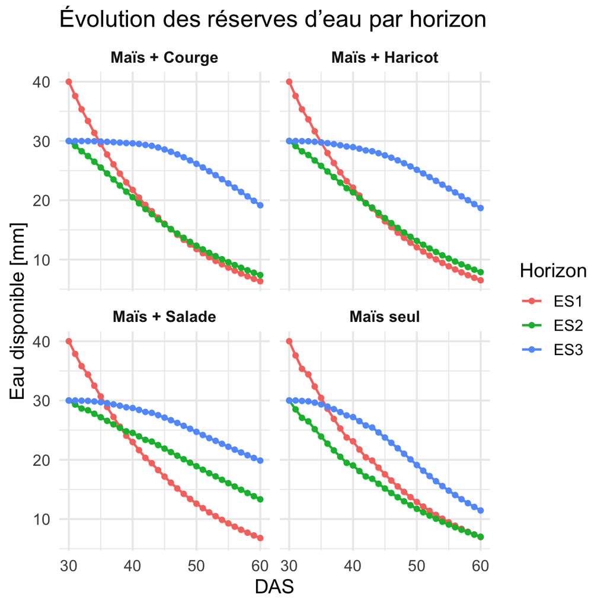

```r
# 1) Concaténation de toutes les simulations en ajoutant une colonne Culture
df_water_all <- bind_rows(
  resultat_mais               %>% mutate(Culture = "Maïs seul"),
  resultats_mais_haricot      %>% mutate(Culture = "Maïs + Haricot"),
  resultats_mais_courge       %>% mutate(Culture = "Maïs + Courge"),
  resultats_mais_salade       %>% mutate(Culture = "Maïs + Salade")
) %>%
  # 2) Sélection et mise en format long
  dplyr::select(Culture, Jour, ES1, ES2, ES3) %>%
  pivot_longer(
    cols      = starts_with("ES"),
    names_to  = "Horizon",
    values_to = "Eau_mm"
  )

# 3) Tracé en facettes
ggplot(df_water_all, aes(x = Jour, y = Eau_mm, color = Horizon)) +
  geom_line(size = 0.8) +
  geom_point(size = 1.5) +
  facet_wrap(~ Culture, ncol = 2) +
  labs(
    title = "Évolution des réserves d’eau par horizon",
    x     = "DAS",
    y     = "Eau disponible [mm]",
    color = "Horizon"
  ) +
  theme_minimal(base_size = 14) +
  theme(strip.text = element_text(face = "bold"))
```

```r
# 4) Table pour connaitre les niveaux d'eau à J60
table_end60 <- df_water_all %>%
  filter(Jour == 60) %>%
  dplyr::select(Culture, Horizon, Eau_mm) %>%
  pivot_wider(
    names_from  = Horizon,
    values_from = Eau_mm
  )

  # Affichage de la table
  knitr::kable(
    table_end60,
    col.names = c("Scénario", "Horizon 1 (mm)", "Horizon 2 (mm)", "Horizon 3 (mm)"),
    caption   = "Eau disponible à J60 par horizon et par scénario"
  )
```

Eau disponible à J60 par horizon et par scénario

| Scénario | Horizon 1 (mm) | Horizon 2 (mm) | Horizon 3 (mm) |
| --- | --- | --- | --- |
| Maïs seul | 6.938496 | 7.020214 | 11.44389 |
| Maïs + Haricot | 6.504094 | 7.874594 | 18.68976 |
| Maïs + Courge | 6.344074 | 7.385780 | 19.15622 |
| Maïs + Salade | 6.804305 | 13.327646 | 19.86248 |

- Épuisement prioritaire de l’horizon 1 :  
  Dans tous les scénarios, c’est l’horizon superficiel (ES1) qui est le plus fortement vidé (de ~40 mm à ~6–7 mm entre J30 et J60). Les différences entre monoculture et intercultures sont faibles ici : ES1 résiduel compris entre 6,3 mm pour « Maïs+Courge » et 6,9 mm pour le maïs seul, ce qui montre que quel que soit le voisin, le maïs exploite d’abord la couche 1.
- Comportement divergent en horizon 2:  
  En monoculture, ES2 passe de ~30 mm à seulement 7 mm résiduels à J60, alors que dans l’association maïs–salade, on observe 13,3 mm dans le deuxième horizon. Les intercultures « maïs+haricot » et « maïs+courge » conservent quant à elles ~7,4–7,9 mm. Cela suggère que la salade, vraisemblablement par un schéma racinaire plus superficiel ou une moindre demande transpiratoire, limite l’extraction dans la zone médiane.
- Réserve profonde dans l’horizon 3 :  
  Quantitée d’eau résiduelle beaucoup plus élevée en interculture
  - Maïs seul : 11,4 mm résiduels
  - Maïs+Haricot : 18,7 mm
  - Maïs+Courge : 19,2 mm
  - Maïs+Salade : 19,9 mm
  - Le maïs en monoculture puise donc beaucoup plus profondément (ne laissant que ~11 mm) que lorsqu’il est associé à un autre couvert. Les intercultures conservent presque 2× plus d’eau dans le dernier horizon, signe d’une compétition réduite ou d’une complémentarité racinaire (chaque espèce « se partage » moins la ressource profonde).
- Implications agronomiques :
  - Monoculture : extraction forte et uniforme sur tout le profil, risque de stress plus précoce si la recharge est limitée.
  - Intercultures : moindre exploitation des horizons moyens et profonds par le maïs, avec une conservation potentielle de la ressource en eau pour les stades ultérieurs ou pour l’autre espèce.  
    L’association maïs–salade est la plus économe en eau médiane et profonde, ce qui peut être recherché dans des systèmes à faible pluviométrie ou pour limiter le risque d’assèchement rapide.

En résumé, si l’horizon 1 est systématiquement drainé en priorité, les intercultures modulent sensiblement l’exploitation des horizons 2 et 3 : la monoculture creuse le profil jusqu’au profond, alors que les coproductions – et tout particulièrement maïs–salade – laissent une part significative de ressource en eau dans les couches moyennes et profondes.

```r
# Calcul des statistiques descriptives par culture et horizon
df_stats <- df_water_all %>%
  group_by(Culture, Horizon) %>%
  summarise(
    mean_Eau = mean(Eau_mm),
    sd_Eau   = sd(Eau_mm),
    .groups  = "drop"
  )
print(df_stats)
```

```
## # A tibble: 12 × 4
##    Culture        Horizon mean_Eau sd_Eau
##    <chr>          <chr>      <dbl>  <dbl>
##  1 Maïs + Courge  ES1         18.5  10.0
##  2 Maïs + Courge  ES2         17.1   7.17
##  3 Maïs + Courge  ES3         26.9   3.49
##  4 Maïs + Haricot ES1         18.7   9.96
##  5 Maïs + Haricot ES2         17.7   6.99
##  6 Maïs + Haricot ES3         26.3   3.64
##  7 Maïs + Salade  ES1         19.3  10.0
##  8 Maïs + Salade  ES2         21.7   5.03
##  9 Maïs + Salade  ES3         26.2   3.37
## 10 Maïs seul      ES1         19.4   9.85
## 11 Maïs seul      ES2         16.2   6.88
## 12 Maïs seul      ES3         22.4   6.36
```

### 4.2.2 Évolution du ratio Offre/Demande (O/D)

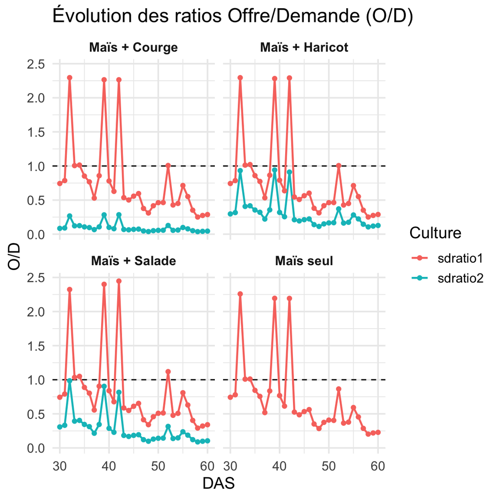

```r
# 1) Concaténation de tous les scénarios
df_od_all <- bind_rows(
  resultat_mais               %>% mutate(Scenario = "Maïs seul")%>% rename(sdratio1 = O_D),
  resultats_mais_haricot      %>% mutate(Scenario = "Maïs + Haricot"),
  resultats_mais_courge       %>% mutate(Scenario = "Maïs + Courge"),
  resultats_mais_salade       %>% mutate(Scenario = "Maïs + Salade")
) %>%
  pivot_longer(
    cols = c(starts_with("sdratio")),
    names_to  = "Culture",
    values_to = "OD",
    values_drop_na = TRUE
  )

# 3) Tracé en facettes
ggplot(df_od_all, aes(x = Jour, y = OD, color = Culture)) +
  geom_hline(yintercept = 1, linetype = "dashed", color = "black") +
  geom_line(size = 0.8) +
  geom_point(size = 1.5) +
  facet_wrap(~ Scenario, ncol = 2) +
  labs(
    title = "Évolution des ratios Offre/Demande (O/D)",
    x     = "DAS",
    y     = "O/D",
    color = "Culture"
  ) +
  theme_minimal(base_size = 14) +
  theme(strip.text = element_text(face = "bold"))
```

Tableau 1 : Jours où le ratio Offre/Demande (O/D) est inférieur à 1

| Scénario | Nombre de jours de stress hydrique |
| --- | --- |
| Maïs seul | 26 |
| Maïs + Haricot | 31 |
| Maïs + Courge | 31 |
| Maïs + Salade | 31 |